[Ghezae Fisseha](https://gafstar.github.io/)

# A Step by Step Machine Learning Approach on Portguese Bank Marketing Strategy

June 1, 2021 in [Machine Learning](https://gafstar.github.io/categories/machine-learning)

### A Step by Step Machine Learning Approach on Porguese Bank Marketing Strategy

This data comes from UCI Machine Learning Repository. From analyzing this data, I believe there are some insights that can be applied to other companies strategy in acquiring new clients.

[Moro et al., 2014] S. Moro, P. Cortez and P. Rita. A Data-Driven Approach to Predict the Success of Bank Telemarketing. Decision Support Systems, Elsevier, 62:22-31, June 2014

A free copy of the paper can be found in the following [link](http://repositorium.sdum.uminho.pt/bitstream/1822/30994/1/dss-v3.pdf).

Note: Throughout the post, I have used the word `subscribe` often to denote if the phone call would result in long term deposit. The converses is true as well, `not subscribe` would refer to the chances of a phone call will not result in long term deposit.

First let's break down the some the terminologies.

#### What is marketing strategy?

Marketing strategy is a long-term, forward-looking approach to planning with the fundamental goal in sustainable advantage. Or simply put, it is a business plan for reaching people and turning them into customers of the business product or services.

What is marketing campaign?

**Marketing campaing** is the process of promoting a product or service with different media, including but not limited to newspapers, tv, online platforms like social media. Marketing campaign is one piece of overall marketing strategy executed with particular goal. A successful marketing campaign comprises of many factors. Some of them are:

1. Knowing how your marketing fits into your marketing plan
2. Setting marketing campaign's objective and parameters
3. Metrics for measuring success
4. Setting marketing campaign budget
5. Choosing marketing strategy to communicate with customers
6. Creating timeline and Action plan

What is deposit?

**Deposit** is a financial term that has multiple meanings. In this refers to the transaction of funds to another party (i.e Banks) with a fixed rate for safekeeping and being able to withdraw it at maturity time. In other words deposit is the money that a customer transfers into the saving or checking account held in a bank.

Now we have defined what marketing strategy and deposit means, let's start looking at the data to get some insight before we apply machine learning.

## Prelimenary data analysis

### Data Description

The data consists of 17 mixed (categorical and numeric) features with no missing value.

**Other attributes:**

Output variable (desired target):

- **y** has the client subscribed a term deposit? (binary: 'yes','no')

Let's load the necessary libraries and the data.

```python
# Loading required libraries
import pandas as pd
import numpy as np
import matplotlib.pyplot as plt
import seaborn as sns
from sklearn import preprocessing
from sklearn.model_selection import train_test_split
from IPython.core.interactiveshell import InteractiveShell
InteractiveShell.ast_node_interactivity = "all"
```

```python
# Load the pbms data
PATH = '/Users/appleuser/Desktop/blogs/pbms/'
df = pd.read_csv(PATH + 'bank-full.csv', sep= ';' )

# Making a deep-copy to practice with different ideas without making changes to the original data
deposits = df.copy()
# display all the columns
pd.set_option('display.max_columns', None)
print (f'The dataset has {df.shape[0]} rows and {df.shape[1]} columns')
df.head(5)
```

```
The dataset has 45211 rows and 17 columns
```

|  | age | job | marital | education | default | balance | housing | loan | contact | day | month | duration | campaign | pdays | previous | poutcome | y |
| --- | --- | --- | --- | --- | --- | --- | --- | --- | --- | --- | --- | --- | --- | --- | --- | --- | --- |
| 0 | 58 | management | married | tertiary | no | 2143 | yes | no | unknown | 5 | may | 261 | 1 | -1 | 0 | unknown | no |
| 1 | 44 | technician | single | secondary | no | 29 | yes | no | unknown | 5 | may | 151 | 1 | -1 | 0 | unknown | no |
| 2 | 33 | entrepreneur | married | secondary | no | 2 | yes | yes | unknown | 5 | may | 76 | 1 | -1 | 0 | unknown | no |
| 3 | 47 | blue-collar | married | unknown | no | 1506 | yes | no | unknown | 5 | may | 92 | 1 | -1 | 0 | unknown | no |
| 4 | 33 | unknown | single | unknown | no | 1 | no | no | unknown | 5 | may | 198 | 1 | -1 | 0 | unknown | no |

```python
df.info()
```

```
<class 'pandas.core.frame.DataFrame'>
RangeIndex: 45211 entries, 0 to 45210
Data columns (total 17 columns):
 #   Column     Non-Null Count  Dtype
---  ------     --------------  -----
 0   age        45211 non-null  int64
 1   job        45211 non-null  object
 2   marital    45211 non-null  object
 3   education  45211 non-null  object
 4   default    45211 non-null  object
 5   balance    45211 non-null  int64
 6   housing    45211 non-null  object
 7   loan       45211 non-null  object
 8   contact    45211 non-null  object
 9   day        45211 non-null  int64
 10  month      45211 non-null  object
 11  duration   45211 non-null  int64
 12  campaign   45211 non-null  int64
 13  pdays      45211 non-null  int64
 14  previous   45211 non-null  int64
 15  poutcome   45211 non-null  object
 16  y          45211 non-null  object
dtypes: int64(7), object(10)
memory usage: 5.9+ MB
```

We see that most of the types are inferred correclty. The data type object refers to a string value. The column y refers whether the customer deposited or not. Currently, it is categorical with two values, "yes" and "no". For binary classification, the model expects a number 0 or 1.

```python
# convert from categorical to integer
df['y'] = df['y'].map({'yes': 1, 'no':0})
```

We did a bit of preprocessing for data. Now, lets put some data for testing. We are going to put away about one fifth (20%) of the data. The `train_test_split` module shuffles the dataframe `df` and creates two separate dataframes with 20% as test set and the remaining 80% as full training set.

Similarly, we split the full training set into four-fifth (4/5) training set and (1/5) validation set.

```python
# Splitting the dataset into training, validation and test shuffled subsets
from sklearn.model_selection import train_test_split
df_train_full, df_test = train_test_split(df, test_size = 0.2, random_state = 11)

df_train, df_val = train_test_split(df_train_full, test_size = 0.2, random_state = 11)
y_train = df_train.y.values
y_val = df_val.y.values
y_train_full = df_train_full.y.values

print(df_train_full.shape, df_test.shape, df_train.shape, df_val.shape)
```

```
(36168, 17) (9043, 17) (28934, 17) (7234, 17)
```

```python
df_train.head()
```

|  | age | job | marital | education | default | balance | housing | loan | contact | day | month | duration | campaign | pdays | previous | poutcome | y |
| --- | --- | --- | --- | --- | --- | --- | --- | --- | --- | --- | --- | --- | --- | --- | --- | --- | --- |
| 32251 | 38 | blue-collar | married | primary | no | 290 | yes | no | cellular | 16 | apr | 283 | 1 | -1 | 0 | unknown | 0 |
| 5131 | 31 | technician | married | secondary | no | 510 | yes | no | unknown | 21 | may | 117 | 3 | -1 | 0 | unknown | 0 |
| 19815 | 30 | technician | single | tertiary | no | 2427 | no | no | cellular | 8 | aug | 261 | 2 | -1 | 0 | unknown | 0 |
| 30340 | 36 | blue-collar | single | secondary | no | 1598 | yes | no | cellular | 5 | feb | 208 | 1 | -1 | 0 | unknown | 0 |
| 14705 | 50 | admin. | married | secondary | no | 219 | yes | no | cellular | 15 | jul | 419 | 7 | -1 | 0 | unknown | 0 |

If you notice the index, it is shuffled this time after it is split in training and test set. This assures as that the rows are randomized, which is critical in when creating a robust machine learning model.

Now, let's get rid of the `y` label from the training and validation dataset. We don't need it anymore.

```python
# delete the target variable from the predictors dataframe
del df_train['y']
del df_val['y']
```

### Exploratory Data Analysis

Exploratory data analysis is an important step in understanding the dataset by summarizing the attributes. The exploratory data analysis process entails checking and handling missing values, outliers, understanding the relationship (correlation) or lack of between variables ...etc. This will help us have some insight into what our data looks like. Exploratory data analysis may include data preparation which take most of the time in a machine learning project.

Let's look if we have any missing values in each of the columns:

```python
# check if there is missing value
df_train_full.isnull().sum()
```

```
age          0
job          0
marital      0
education    0
default      0
balance      0
housing      0
loan         0
contact      0
day          0
month        0
duration     0
campaign     0
pdays        0
previous     0
poutcome     0
y            0
dtype: int64
```

We don't see any missing value in all of the columns. It is important to check for missing values because many machine learning models can't easily deal with it. Tree-based models are good at handling datasets with missing values. However, if you are using other types of models, it is very important to fill in the missing values or drop them from your data. As we can see our data doesn't have missing values, so we continue to explore the data without worrying on dropping or imputing missing values. Here we are only checking if the dataset contains `NAN` or `None` values. However, if we might other missing values which are represented by `unknown`. We will discuss about it at the end of our analysis. For now, let's proceed with other analysis.

Another thing that we should check is the distribution of our target variable.

```python
# check target variable distribution
df_train_full.y.value_counts(normalize = True)
```

```
0    0.882825
1    0.117175
Name: y, dtype: float64
```

There about 88% of class 0 or people who didn't subscribe and about 11% of them subscribed to term deposit. There is another way to calculate the subscription proportion using the `mean()` method.

```python
# find the global mean for unsuccesful long term deposit calls
global_mean = df_train_full.y.mean()
round(global_mean, 3)
```

```
0.117
```

We see there is big difference between the proportions of those whowho didn't subscrib and those who subscribed. The people who didn't subscribe (88%) are about 7 times more than those who subscribed (12%). This is a strong indication of class imbalance in our data and we should address that when we are building a model and use proper evaluation metric that takes into account class imbalance.

Let's dig into our variables. Earlier we saw that we have two types of variables: categorical and numerical. The categorical variables have data type as `object`, while the numerical variables are `int`.

```python
# select only categorical data types
categorical = df.select_dtypes(include=["object"]).columns.to_list()
categorical

# select only numerical data types
numerical = df.select_dtypes(exclude=["object"]).columns.to_list()
numerical.remove('y')
numerical
```

```
['job',
 'marital',
 'education',
 'default',
 'housing',
 'loan',
 'contact',
 'month',
 'poutcome']
```

```
['age', 'balance', 'day', 'duration', 'campaign', 'pdays', 'previous']
```

From the numerical variables we excluded our target variable `y`. Remember, y was a categorical variable initially, however, we converted it to numerical variable so that it would be easily handled by Pandas and Sklearn packages in python.

```python
# find unique values in each variable
df_train_full[categorical].nunique()
```

```
job          12
marital       3
education     4
default       2
housing       2
loan          2
contact       3
month        12
poutcome      4
dtype: int64
```

### Feature importance

Knowing how the variables affect the target variable is a key to understanding the data and building a good model. This process is called feature importance analysis. It is often used as part of the exploratory data analysis where it helps identify which variables have greater influence on the whether the phone call will result in long term deposit or not. It helps us answer questions like 'what makes a potential customer sign up for long term deposit or what are the characteristics of customers who don't sign up for long term deposit. Analyzing such questions at the beginning could gives some insight into factors affecting customer decision. We have different kinds of data types. Each has a different way of measuring feature importance, so first let's start looking at the categorical variables and then we will continue with numerical features.

For each categorical variable, we can look at the long term deposit rate. This would give us the breakdown by the category values. For example, let's consider having how having defaulted on credit affects subscribing to term deposit.

```python
# checking long term deposit rate for those who defaulted their loan and those who didn't
defaulted_mean = df_train_full[df_train_full['default'] == 'yes'].y.mean()
print(f'default = yes : {round(defaulted_mean,2)}')
not_defaulted_mean = df_train_full[df_train_full['default'] == 'no'].y.mean()
print(f'default = no : {round(not_defaulted_mean,2)}')
```

```
default = yes : 0.07
default = no : 0.12
```

We see that only around 7% of people with defaulted credit have long term deposit and 12% of those who didn't default have resulted in long term deposit, while the global long term deposit rate is 12%. The difference between subscription rate for both who defaulted and who didn't is quite small, which indicates knowing whether the customer defaulted or not doesn't help us identify whether a phone call will result in long term deposit.

```python
# proportions of defaulted mean to global
defaulted_mean / global_mean
```

```
0.6057407592117584
```

```python
# proportion of non-defaulted mean to global mean
not_defaulted_mean / global_mean
```

```
1.0070343996921187
```

Now let's look at another variable: housing. It has two values, yes and no, so there are two groups of customers: those who have a housing loan (indicate as housing == 'yes') and those who don't (indicated as housing == 'no'). We can check the group subscription using the same code as above, but we change the filter condition.

```python
# checking long term deposit rate for those who have housing loan and those who don't
house_mean = df_train_full[df_train_full['housing'] == 'yes'].y.mean()
print(f'housing = yes : {round(house_mean,2)}')
no_house_mean = df_train_full[df_train_full['housing'] == 'no'].y.mean()
print(f'housing = no : {round(no_house_mean,2)}')
```

```
housing = yes : 0.08
housing = no : 0.17
```

### Risk ratio

In addition to looking the difference between group subscription rate and the global rate, it is interesting to look at the ratio between them. In statistics, the ratio between the probabilities of differing groups is called **risk ratio**.

risk = group rate / global rate

risk = 0.17 / 0.12 = 1.42

If the group rate and global rate are almost equal, then they have the same risk level. However, if the risk number is less than one, we say there low risk level.

```python
# ratio of customers with no housing loan
no_house_mean
```

```
0.16777398323502019
```

```python
# risk ratio for thos who have house loan
house_mean / global_mean
```

```
0.6533695405014553
```

```python
# risk ratio for those who don't have house loan
no_house_mean / global_mean
```

```
1.4318191188400684
```

```python
df_group = df_train_full.groupby('housing').y.agg(['mean'])
df_group['diff'] = df_group['mean'] - global_mean
df_group['risk'] = df_group['mean'] / global_mean
df_group
```

| housing | mean | diff | risk |
| --- | --- | --- | --- |
| no | 0.167774 | 0.050599 | 1.431819 |
| yes | 0.076559 | -0.040617 | 0.653370 |

```python
# import display module for displaying tables in html format
from IPython.display import display
# global long deposit mean
global_mean = df_train_full.y.mean()
global_mean
```

```
0.11717540367175404
```

```python
# removing high cardinal columns and keeping columns with less than 4 categories
cat = ['marital','education','default','housing','loan','contact', 'poutcome']

# checking mean, diff and risk for all columns with less than 5 categries

for col in cat:
    df_group = df_train_full.groupby(col).y.agg(['mean'])
    df_group['diff'] = df_group['mean'] - global_mean
    df_group['risk'] = df_group['mean'] / global_mean
    display(df_group)
```

| marital | mean | diff | risk |
| --- | --- | --- | --- |
| divorced | 0.119971 | 0.002796 | 1.023860 |
| married | 0.102655 | -0.014521 | 0.876078 |
| single | 0.146967 | 0.029791 | 1.254246 |

| education | mean | diff | risk |
| --- | --- | --- | --- |
| primary | 0.087530 | -0.029646 | 0.746998 |
| secondary | 0.104707 | -0.012468 | 0.893592 |
| tertiary | 0.151802 | 0.034627 | 1.295515 |
| unknown | 0.133289 | 0.016114 | 1.137518 |

| default | mean | diff | risk |
| --- | --- | --- | --- |
| no | 0.118000 | 0.000824 | 1.007034 |
| yes | 0.070978 | -0.046197 | 0.605741 |

| housing | mean | diff | risk |
| --- | --- | --- | --- |
| no | 0.167774 | 0.050599 | 1.431819 |
| yes | 0.076559 | -0.040617 | 0.653370 |

| loan | mean | diff | risk |
| --- | --- | --- | --- |
| no | 0.126551 | 0.009375 | 1.080010 |
| yes | 0.067855 | -0.049320 | 0.579092 |

| contact | mean | diff | risk |
| --- | --- | --- | --- |
| cellular | 0.149106 | 0.031930 | 1.272499 |
| telephone | 0.131590 | 0.014415 | 1.123019 |
| unknown | 0.041526 | -0.075650 | 0.354390 |

| poutcome | mean | diff | risk |
| --- | --- | --- | --- |
| failure | 0.125541 | 0.008366 | 1.071395 |
| other | 0.155976 | 0.038800 | 1.331130 |
| success | 0.644192 | 0.527016 | 5.497670 |
| unknown | 0.092147 | -0.025029 | 0.786400 |

### Mutual information

The above methods we have discussed so far are useful for analyzing and understanding our data, but it is hard to distinguish which ones are most important features. Luckily, by measuring the degree of dependency between a categorical variable and the target variable, we would be able to know how important that variable is.

```python
# import mutual_info_score
from sklearn.metrics import mutual_info_score

# Create a mutual info funciton that is applied to each of the categorical features
def calculate_mi(series):
    return mutual_info_score(series, df_train_full.y)

df_mi = df_train_full[cat].apply(calculate_mi)
df_mi = df_mi.sort_values(ascending = False).to_frame(name = 'MI')

display(df_mi.head(10))
```

|  | MI |
| --- | --- |
| poutcome | 0.029316 |
| contact | 0.013268 |
| housing | 0.009910 |
| education | 0.002723 |
| loan | 0.002522 |
| marital | 0.001774 |
| default | 0.000210 |

```python
# mean value summary for numerical features that result to long term deposit
df_train_full.groupby('y')[numerical].mean()
```

| y | age | balance | day | duration | campaign | pdays | previous |
| --- | --- | --- | --- | --- | --- | --- | --- |
| 0 | 40.818071 | 1306.016442 | 15.896461 | 220.859098 | 2.844472 | 36.707172 | 0.507986 |
| 1 | 41.702690 | 1785.578339 | 15.149127 | 539.266871 | 2.130958 | 68.701982 | 1.157622 |

## Building Machine Learning Models

### Feature Engineering

So far we had an initial look at our data. We also tried to understand which features affect whether a phone call will result in long term deposit.

Feature engineering is an important step in machine learning project where we brain strom or test features, decide what features to create, test impact of identified features on the task or improve features if needed. However, in this example we are going to encode the categorical features with one-hot-encoding before we proceed to training the model.

### One-hot encoding

When working with machine learning models, we just can't take and put categorical variables in the model, because models can only deal with numbers in matrices. So we need to encoode the categorical variables to numbers.

One such technique used for encoding is one-hot encoding.

This approach has the advantage of not weighing a value improperly as it coverts each category value in a new column and assigning it 1 or 0 (T/F) value to the column. For instance, the variable marital has values (single, married and divorced), we can represent a custoemr with married marital status as (0,1,0). In this case, the married marital status is active or **hot**, so it gets 1, while the remaining are not active or **cold**, so they are 0.

```python
# Import DictVectorizer that enables one-hot-encoding
from sklearn.feature_extraction import DictVectorizer
```

```python
# Convert the categorical and numberical features into dictionary
train_dict = df_train[cat + numerical].to_dict(orient = 'records')
print(train_dict[0])
```

```
{'marital': 'married', 'education': 'primary', 'default': 'no', 'housing': 'yes', 'loan': 'no', 'contact': 'cellular', 'poutcome': 'unknown', 'age': 38, 'balance': 290, 'day': 16, 'duration': 283, 'campaign': 1, 'pdays': -1, 'previous': 0}
```

```python
# one-hot-encoding
dv = DictVectorizer(sparse = False)
dv.fit(train_dict)
X_train = dv.transform(train_dict)
print(X_train.shape)
dv.get_feature_names()
```

```
DictVectorizer(sparse=False)
```

```
(28934, 27)
```

```
['age',
 'balance',
 'campaign',
 'contact=cellular',
 'contact=telephone',
 'contact=unknown',
 'day',
 'default=no',
 'default=yes',
 'duration',
 'education=primary',
 'education=secondary',
 'education=tertiary',
 'education=unknown',
 'housing=no',
 'housing=yes',
 'loan=no',
 'loan=yes',
 'marital=divorced',
 'marital=married',
 'marital=single',
 'pdays',
 'poutcome=failure',
 'poutcome=other',
 'poutcome=success',
 'poutcome=unknown',
 'previous']
```

Les't first import all the modules, functions and objects we will use in building up the candidate models.

```python
# Importing necessary libraries for modeling
import matplotlib.pyplot as plt
from sklearn.model_selection import train_test_split
from sklearn.model_selection import KFold
from sklearn.model_selection import cross_val_score
from sklearn.metrics import accuracy_score, classification_report, confusion_matrix, precision_score, recall_score
from sklearn.metrics import plot_confusion_matrix
from sklearn.linear_model import LogisticRegression
from sklearn.tree import DecisionTreeClassifier
from sklearn.neighbors import KNeighborsClassifier
from sklearn.discriminant_analysis import LinearDiscriminantAnalysis
from sklearn.naive_bayes import GaussianNB
from sklearn.svm import SVC
```

### Build Models

```python
# Create multiple models with mean accuracy score and standard deviation
import warnings
warnings.filterwarnings("ignore")

models = []
models.append(('LR', LogisticRegression()))
models.append(('LDA', LinearDiscriminantAnalysis()))
models.append(('KNN', KNeighborsClassifier()))
models.append(('CART', DecisionTreeClassifier()))
models.append(('NB', GaussianNB()))
# models.append(('SVM', SVC()))
# evaluate each model in turn
results = []
names = []

results_mean = []
results_std = []

for name, model in models:
    kfold = KFold(n_splits=10)
    cv_results = cross_val_score(model, X_train, y_train, cv=kfold, scoring='accuracy')
    results.append(cv_results)
    names.append(name)
    results_mean.append(round(cv_results.mean(),3))
    results_std.append(round(cv_results.std(),3))

results_df = pd.DataFrame({'Models':names, 'mean_score':results_mean, 'std_score':results_std})\
                  .sort_values(by = 'mean_score', ascending = False)
results_df
```

|  | Models | mean_score | std_score |
| --- | --- | --- | --- |
| 1 | LDA | 0.899 | 0.005 |
| 0 | LR | 0.891 | 0.005 |
| 2 | KNN | 0.882 | 0.004 |
| 3 | CART | 0.859 | 0.007 |
| 4 | NB | 0.834 | 0.010 |

### Select The Best Model

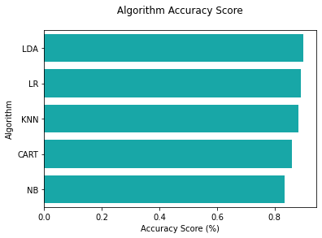

```python
# Plot accuracy results
sns.barplot(x='mean_score', y = 'Models', data = results_df, color = 'c')
plt.title(' Algorithm Accuracy Score \n')
plt.xlabel('Accuracy Score (%)')
plt.ylabel('Algorithm')
plt.show()
```

It looks like the LDA algorithm is the most accurate model on the training dataset. Let's see if our model accuracy is as good or better when we test it with a validation dataset.It is usually a good practice to keep a validation dataset just in case to see if you are overfitting to the training set or have a data leak.

### Make Predictions and Evaluate the Model

We run the LDA model on the validation set and see how it performs. The result summary contains a confusion matrix, an accuracy score and a classifiction report.

First let's transform the validation set by using one-hot-encoding for the categorical values

```python
# one hot encoding for validation data
from sklearn.feature_extraction import DictVectorizer

train_dict2 = df_val[cat + numerical].to_dict(orient = 'records')

print(train_dict2[0])

dv = DictVectorizer(sparse = False)
dv.fit(train_dict2)

X_val = dv.transform(train_dict2)

print(X_val.shape)
```

```
{'marital': 'married', 'education': 'tertiary', 'default': 'no', 'housing': 'no', 'loan': 'no', 'contact': 'cellular', 'poutcome': 'unknown', 'age': 54, 'balance': 4104, 'day': 15, 'duration': 68, 'campaign': 8, 'pdays': -1, 'previous': 0}
```

```
DictVectorizer(sparse=False)
```

```
(7234, 27)
```

Let's make a prediction on the validation dataset and create a classification report to evaluate our model. Will pick up `LinearDiscriminantAnalysis`

```python
# Make predictions on validation dataset
lr = LinearDiscriminantAnalysis()
lr.fit(X_train, y_train)
predictions = lr.predict(X_val)
print(classification_report(y_val, predictions))
```

```
LinearDiscriminantAnalysis()
```

```
              precision    recall  f1-score   support

           0       0.92      0.97      0.94      6387
           1       0.62      0.37      0.46       847

    accuracy                           0.90      7234
   macro avg       0.77      0.67      0.70      7234
weighted avg       0.89      0.90      0.89      7234
```

One of the most important aspects of building a machine learning model is choosing evaluation metric. We have to weigh in different elements of the model to come up with the best evaluation criteria. For instance, in this example, what would be a good metric for the phone call prediction to sell a long term deposits? We can either choose accuracy or f1-score to evaluate our model, however, we have to know when to use either of them. Accuracy is used when True Positives and True Negatives are more important, while f1-score is used when False Negatives and False Positives are important.

Beside accuracy, the confusion matrix is quite a popular metric. This is the one you should always look at besides accuracy.

Precision and recall are two extremely useful metrics from the confusion matrix. Let's see what precision and recall can tell us about the dataset.

1) **Precision:** implies the measure of correctly identified positive cases from all the predicted positive cases. Out of all the phone calls that were predicted to sell long term deposits, what percentage of that actually sold long term deposits?

```python
precision_score(y_true=y_val, y_pred=predictions)
```

```
0.6190476190476191
```

So, in this case we have 62% chance of correctly identifying the positive cases of a call resulting in a long term deposits. This doesn't look great given we have an accuracy of 90%.This is a good indicator of the fact that higher accuracy doesn't necessarily mean better model. Let's see the other metric `recall` if it tells us something better.

2) **Recall:** implies the measure of the correctly identified positive case from all of the actual positive cases. Out of all the phone calls that resulted in long term deposits, what percentage of them the model correctly predicted the result of a phone call to sell long term deposits? This will become a bit clearer when we see the metrics individually on the raw data.

```python
recall_score(y_true=y_val, y_pred=predictions)
```

```
0.36835891381345925
```

The recall of the model is 37%, which is worse than we expected given the accuracy being 90%. This is telling us that out of all customers who made long term deposits, the model was able to correctly identify 37% of them. This result underscores that we should not rely only on accuracy when we are evaluating classification.

```python
# Import seaborn library to create cool visualization
import seaborn as sns
from sklearn import metrics
```

We can also look at the confusion matrix values:

```python
cm = confusion_matrix(y_true=y_val, y_pred=predictions)
cm
```

```
array([[6195,  192],
       [ 535,  312]])
```

or better a plot of the values (TP, FP, TN and FN):

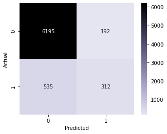

```python
# plotting confusion matrix
df = pd.DataFrame(cm, index=['0', '1'], columns=[
'0', '1'])
cmap = cmap = sns.cubehelix_palette(30, hue = 0.5, rot = 0, light = 0.9, dark = 0, as_cmap = True)
plt.figure(figsize=(5, 4))
sns.heatmap(df, annot=True, cmap= cmap, fmt='g')
plt.xlabel('Predicted')
plt.ylabel('Actual')
plt.show()
```

### Handling Class Imbalance

Most of the time the when dealing with classification predictive modeling, we have unequal observations for each class label. This poses a challenge because most machine learning algorithms are build under the assumption that the target classes have equal number of observations for each class. However, more often than not the distribution of the observation is across the known classes is biased or skewed. For instance, if we are working with fraud detection, we will likely have a the fraud or target class (positive class) as a minority class. So we have to some way of mitigating the class imbalance. There are several machine learning techniques that address this problem. In this post we are going to see only one technique called `Random Oversampling`. It involves randomly selecting examples from the minority class, and adding them to the training dataset, so that the training dataset will end up having about equal number of examples for each class.

Let's first install the imbalance-learn package

```python
!pip install -U imbalanced-learn
```

Let's import the packages that will help us deal with class imbalance. Below, we import `Pipeline`, `RandomOversampler` and `RepeatedStratifiedKFold` validation modules. Please note that the `Pipeline` module is different from `sklean`'s `Pipeline`, hence, we are going to import it from the `imblearn` package.

```python
# Importing libraries to handle data imbalanced
from imblearn.pipeline import Pipeline
from imblearn.over_sampling import RandomOverSampler
from sklearn.model_selection import RepeatedStratifiedKFold
```

We run the model with `random oversampling` and evaluate the f1-score

```python
# Create imbalanced pipeline and check accuracy
steps = [('over', RandomOverSampler()), ('model', LinearDiscriminantAnalysis())]
pipeline = Pipeline(steps=steps)
# evaluate pipeline
kfold = KFold(n_splits=10)
# kfold = RepeatedStratifiedKFold(n_splits=10, n_repeats=3, random_state=1)
scores = cross_val_score(pipeline, X_train, y_train, scoring='f1', cv=kfold, n_jobs=-1)
score = np.mean(scores)

print('F1-Score: %.3f' % score)
```

```
F1-Score: 0.528
```

This is a good progress from 0.46 to 0.53. By just using `random oversampling` technique for addressing the class imbalance we increased the f1-score by 15%. Similarly, we can also try other techniques to handle class imbalance to find out if they give better result than `random oversampling`.

### Using the model

Let's try out our model to see how it works. First, we take a customer that we want to find the probability score. Let's put the variables and the values in a dictionary:

```python
# customer 1 has the following attributes
customer = { 'marital': 'married',
             'education': 'tertiary',
             'default': 'no',
             'housing': 'no',
             'loan': 'no',
             'contact': 'cellular',
             'poutcome': 'unknown',
             'age': 35,
             'balance': 18057,
             'day': 8,
             'duration': 90,
             'campaign': 1,
             'pdays': -1,
             'previous': 0}
```

Now given our `customer` features are in a dictionary, we will convert it to a matrix by using the `DictVectorizer` and then we take the matrix and put it into the trained model:

```python
# One-hot-encoding customer 1 attributes and predicting
X_test = dv.transform([customer])
lr.predict_proba(X_test)[0,1]
```

```
0.028914583308032666
```

There is about 3% chance that the customer would subscribe. This is less than 50%, so we wouldn't waste our time trying to contact the customer again. This would cutoff our cost of acquisition by targeting our efforts to the customers with higher chance of subscribing.

Now, let's see a second customer:

```python
# customer 2 has the following attributes
customer_2 = { 'marital': 'single',
             'education': 'tertiary',
             'default': 'yes',
             'housing': 'yes',
             'loan': 'no',
             'contact': 'cellular',
             'poutcome': 'success',
             'age': 45,
             'balance': 1057,
             'day': 5,
             'duration': 20,
             'campaign': 1,
             'pdays': -1,
             'previous': 1}
```

```python
# One-hot-encoding customer 2 attributes
X_test = dv.transform([customer_2])
lr.predict_proba(X_test)[0,1]
```

```
0.8014714541546828
```

It looks like `customer_2` has about 80% chance of subscribing, which is greater much than 50%. This customer is more likely to subscribe.

### Conclusion

I hope these post provides some ways of approaching a machine learning problem.

### Further Reading

1. **[Random Oversampling and Undersampling for Imbalanced Classification](https://machinelearningmastery.com/random-oversampling-and-undersampling-for-imbalanced-classification/) by Jason Brownlee**
2. **[A Data-Driven Approach to Predict theSuccess of Bank Telemarketing](https://www.sciencedirect.com/science/article/abs/pii/S016792361400061X) by Sergio Moro et al.**
3. **[Bank Marketing Data Set](https://archive.ics.uci.edu/ml/datasets/Bank+Marketing) UCI ML Repository**
4. **[How to Run a Successful Marketing Campaign](https://www.thebalancesmb.com/how-to-run-a-successful-marketing-campaign-2948364) The Balance**
5. **[Machine Learning Bookcamp](https://livebook.manning.com/book/machine-learning-bookcamp/welcome/v-2/) by Alexey Grigorev**

TAGGED IN  
[Python](https://gafstar.github.io/tags/python/)

- [Share on Facebook](https://www.facebook.com/sharer/sharer.php?u=https%3A%2F%2Fgafstar.github.io%2F2021%2F06%2F01%2Fa-step-by-step-machine-learning-approach-on-portguese-bank-marketing-strategy%2F)
- [Share on Twitter](https://twitter.com/intent/tweet?text=https%3A%2F%2Fgafstar.github.io%2F2021%2F06%2F01%2Fa-step-by-step-machine-learning-approach-on-portguese-bank-marketing-strategy%2F)
- [Share on Google+](https://plus.google.com/share?url=https%3A%2F%2Fgafstar.github.io%2F2021%2F06%2F01%2Fa-step-by-step-machine-learning-approach-on-portguese-bank-marketing-strategy%2F)

[figure not shown]

#### Ghezae Fisseha

Data Science | Analytics | Business Intelligence

Data Scientist/Analytics

Redwood City, CA